# COG Text Analysis Workshop

Content Creator: Camille Johnston

Content Editors: Steven Martinez, Katie Jobson, Billy Mitchell, and Helen Schmidt

2023-07-17

[video not shown]

# 1 Load Packages

```r
library(tidyverse) ## Always load tidyverse
library(tidytext) ## Amazing package for all things text analysis
library(tidylo) ## Used to calculate log odds
library(hunspell) ## Used for spellchecking
library(stringi) ## Used for replacing typos
library(ggraph) ## For graphing word clouds
library(igraph) ## For graphing word clouds
library(stopwords) ## for stopwords
```

# 2 Load in data

[video not shown]

This data set has a subject ID, several text boxes, and a rating of how severe the impact of the lying experience was for the participant. This wide format is more or less how the data is exported from REDCap, with one row per participant, and one column per text box.

```r
lying_wide <- read.csv("lying_wide_COG.csv")
```

# 3 Restructure text data and clean

## 3.1 Move all text boxes into one column

To start exploring our text data, we need to unnest our tokens. In other words, we need to restructure the data by splitting the raw data from the text boxes into individual words. In order to unnest tokens from all of the text data at once, I’m going to convert the data into long form, so that all of the text is in one “text” column, and individual text box types are specified by labels in a new “text_box” column. Additionally, I’m reformatting a couple instances where people put NAs and removing empty boxes

```r
lying_long <- lying_wide %>%
  pivot_longer(cols = starts_with("text_"),  ## Pivot the wide columns starting with "text_"
               names_to = "text_box",  ## Create a new column called "text_box for the labels"
               names_pattern = "text_(.*)",  ## Extract the text after "text_ for the labels"
               values_to = "text") %>%  ## Create a new column called "text" for the values (in this case, the text itself)
  mutate(across(text, ~ na_if(.,"N/A"))) %>% ## Reformat to NA when the text box just says "N/A"
  mutate(across(text, ~ na_if(.,"n/a"))) %>% ## Reformat to NA when the text box just says "n/a"
  filter(!is.na(text)) ## Remove empty text boxes
```

## 3.2 Unnest tokens

In this code, we’re using the unnest_tokens() function from the `tidytext` package to break down the text data into individual words. This process, known as *tokenization*, allows us to analyze text at a more granular level. `unnest_tokens()` also normalizes the text data by converting all words to lowercase and removing punctuation, which helps ensure consistency in subsequent analyses. Additionally, we can use `unnest_tokens()` to extract *ngrams*, which are consecutive phrases of a specified length. In the example, I use `n = 2` to extract bigrams (pairs of words). Unnesting tokens provides us with a structured format that facilitates in-depth exploration of the text data.

```r
lying_unnested <- lying_long %>%
  unnest_tokens(word, text) ## Unnest from "text" into new "word"

lying_bigrams <- lying_long %>%
  unnest_tokens(bigram, text, token = "ngrams", n = 2) ## Unnest bigrams from "text" into new "bigram"
```

## 3.3 Generating list of potential typos

[video not shown]

It will be hard to count which words are used a lot if many of the uses are misspelled! We can use the `hunspell` package to pull words that seem like typos and suggest likely corrections. The best part is you can export this as a .csv, tweak the list of typos or their corrections if needed, and reload. Then you also have a record of all words you changed and how!

```r
typo_list <- lying_unnested %>%
  distinct(word) %>%        ## Select unique words
  pull() %>%                ## Extract as a character vector
  hunspell() %>%            ## Spell check the words
  unlist() %>%              ## Unlist the spell check results
  unique() %>%              ## Keep only one of each unique misspelled word
  tibble(typo = .) %>%      ## Convert to tibble with column name "bad.words"
  mutate(typo_correction = map_chr(hunspell_suggest(typo), 1))  ## Pull the first suggestion for each misspelled word
```

## 3.4 Save this list and look for other typos

You’ll notice that some of these are actually totally fine, so you can remove them from the .csv in Excel. Additionally, we’ll look at words that weren’t used very often, to see if there are any others we want to add manually.

```r
## Save draft of potential typos and corrected words
write.csv(typo_list,
          "spellcheck_draft.csv",
          row.names = F)

## Scroll through infrequently used words to look for other typos
lying_unnested %>%
  count(word) %>% ## Count frequency of all tokens
  arrange(n) ## Sort by n, using default ascending order
```

| word | n |
| --- | --- |
| able | 1 |
| above | 1 |
| abuse | 1 |
| ache | 1 |
| acknowledged | 1 |
| acknowledgement | 1 |
| addressing | 1 |
| affecting | 1 |
| air | 1 |
| alignment | 1 |

[output cut: 1672 more lines]

## 3.5 Loading in and correcting list of hand-corrected typos

Assuming you made some tweaks, let’s load in our final list of typos and corrections

```r
## Load in final list of typos and corrections
typo_list <- read.csv("spellcheck_FINAL.csv",
                      stringsAsFactors = FALSE)

## Create a character vector of whole word typo matches, specifying word boundaries
whole_word_typos <- paste0("\\b", typo_list$typo, "\\b")

## Create a character vector of all corrections
typo_corrections <- typo_list$typo_correction

## Replace misspelled words in the 'word' column of 'lying_unnested' with corrections
lying_unnested$word <- stri_replace_all_regex(lying_unnested$word, whole_word_typos, typo_corrections,
                                                    vectorize_all = FALSE)

## Replace misspelled words in the 'bigram' column of 'lying_bigrams' with corrections
lying_bigrams$bigram <- stri_replace_all_regex(lying_bigrams$bigram, whole_word_typos, typo_corrections,
                                                     vectorize_all = FALSE)
```

## 3.6 Make dataframe of word counts

[video not shown]

Now that we have spellchecked our words, we want to prepare to explore most used words, etc. We’ll group by words so that we only have one row per word. Additionally, we’ll average across severity, so that we can see which words were used by people with more/less impactful experiences.

```r
## Single words
token_counts <- lying_unnested %>%
  group_by(word) %>% ## Group the data by word
  summarise(n = n(), ## Count the occurrences of each word
            rating_impact_severity = mean(rating_impact_severity, na.rm=TRUE)) %>%  ## Calculate the mean of rating_impact_severity for each word
  arrange(-n) ## Arrange the data in descending order of counts

## Bigrams
bigram_counts <- lying_bigrams %>%
  group_by(bigram) %>% ## Group the data by bigram
  summarise(n = n(), ## Count the occurrences of each bigram
            rating_impact_severity = mean(rating_impact_severity, na.rm=TRUE)) %>% ## Calculate the mean of rating_impact_severity for each word
  arrange(-n) ## Arrange the data in descending order of counts
```

## 3.7 Make dataframe of word counts per prompt

It might not be super useful to count up all word uses across the whole project. Instead, what may be more important to you is which words were used most per **PROMPT** (i.e., per text box) We can use the same code and just make sure we group by `text_box` as well

```r
token_counts_grouped <- lying_unnested %>%
  group_by(text_box, word) %>% ## Group the data by text box and word
  summarise(n = n(), ## Count the occurrences of each word
            rating_impact_severity = mean(rating_impact_severity, na.rm=TRUE)) %>%  ## Calculate the mean of rating_impact_severity for each word
  arrange(-n) ## Arrange the data in descending order of counts
```

# 4 Let’s make some graphs!

[video not shown]

## 4.1 Frequently used words per prompt

Here we will do some fancy ggplotting to view the most common words for each prompt. Try it first without the `anti_join()` at the beginning, which will give you the raw frequencies. As you may have guessed, words like “I”, “you”, “the”, etc. are used the most in almost all text you’ll come across. This can provide super useful information, but for the purposes of *THIS* graph, they are not very informative. There are existing lists of stop words that you can remove with an `anti_join()` you can also make a custom list! Two of the pre-existing ones I’ve used are `get_stopwords()`, which is a relatively shorter list, and `stop_words`, which is more comprehensive

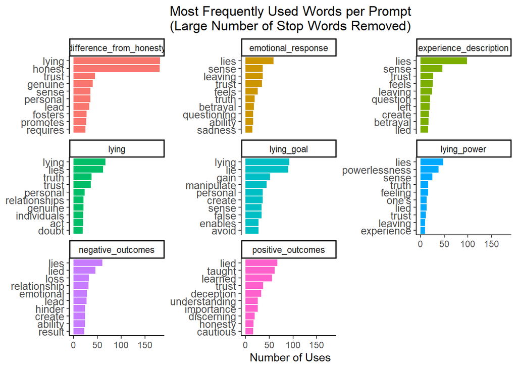

```r
lying_unnested %>%
  ## Try with the following line commented out first, and then try with it in. You can also try "anti_join(get_stopwords()) %>%"
  anti_join(stop_words) %>% ## Remove a lot of common stop words
  group_by(text_box) %>% ## Group the data by text_box
  count(word, sort = TRUE) %>% ## Count the occurrences of each word, sorted in descending order
  slice_max(n, n = 10, with_ties = FALSE) %>% ## Keep only the top 20 words with the highest counts
  ungroup() %>%  ## Remove grouping
  ggplot(aes(n,
             reorder_within(word, n, text_box),
             fill = text_box)) +  ## Create a ggplot object, reordering words and varying the color
  geom_col(show.legend = FALSE) + ## Add a column plot
  scale_y_reordered() + ## Reorder y-axis labels based on counts
  facet_wrap(vars(text_box), scales = "free_y") +  ## Add facet wrap for multiple plots
  theme_classic() + ## Apply a classic theme
  theme(plot.title = element_text(hjust = 0.5), axis.text.y = element_text(size = 10)) + ## Adjust plot theme
  labs(x = "Number of Uses",
       y = NULL,
       title = "Most Frequently Used Words per Prompt\n(Large Number of Stop Words Removed)") ## Set axis and plot titles
```

## 4.2 Calculating high importance words

Another metric is using *log odds*, which calculates the likelihood that a word appears in a specific document (or in this case, prompt) compared to its overall likelihood of appearing in any prompt. It is a little more forgiving than tf-idf if one term shows up in many prompts. The `tidylo` package allows us to calculate log odds using an empirical Bayes Dirichlet prior approach or an uninformative prior. The difference between the two is how prior information is incorporated into the calculation.

In the empirical Bayes Dirichlet prior approach, prior information from the entire dataset is used to adjust the log odds calculation. This approach takes into account the overall distribution of word frequencies across all prompts, providing a more informed estimate of the likelihood of a word in a specific prompt.

On the other hand, the uninformative prior approach does not incorporate prior information. It assumes equal probabilities for all words and treats each prompt independently, without considering the overall distribution of word frequencies.

In the code block provided, we are binding both tf-idf and log odds metrics to the dataset, resulting in a new dataframe called `lying_unnested_info`. This dataframe contains columns for tf-idf, weighted log odds with an informative prior (`wlo_informative`), and weighted log odds with an uninformative prior (`wlo_uninformative`).

```r
lying_unnested_info <- lying_unnested %>%
  count(text_box, word, sort = TRUE) %>%  ## Count occurrences of each word within each text_box
  bind_tf_idf(word, text_box, n) %>%  ## Calculate tf-idf for each word within each text_box
  bind_log_odds(text_box, word, n) %>%  ## Calculate log odds for each word within each text_box
  rename(wlo_informative = log_odds_weighted) %>%  ## Rename column to reflect log odds with informative priors
  bind_log_odds(text_box, word, n, uninformative = TRUE) %>% ## Calculate log odds with uninformative priors
  rename(wlo_uninformative = log_odds_weighted)  ## Rename column to reflect log odds with uninformative priors
```

## 4.3 Visualization of most representative words by TF-IDF

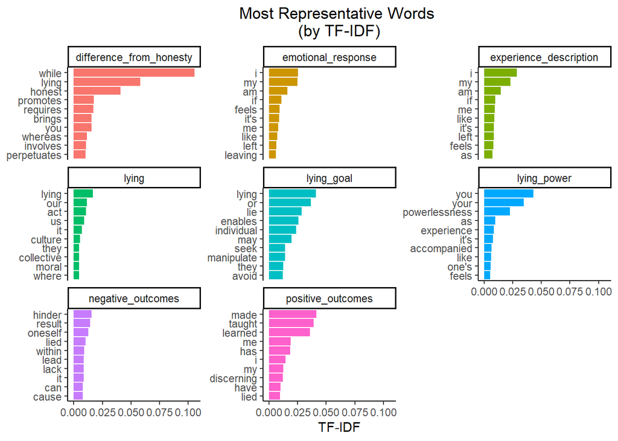

```r
lying_unnested_info %>%
  group_by(text_box) %>% ## Group by prompt
  slice_max(tf_idf, n = 10, with_ties = FALSE) %>%  ## Select the top 20 words with the highest TF-IDF values
  ungroup() %>%
  ggplot(aes(tf_idf,
             reorder_within(word, tf_idf, text_box),
             fill = text_box)) +  ## Map TF-IDF values to x-axis, reorder words within each text_box, and use different colors
  geom_col(show.legend = FALSE) +  ## Create a column chart
  scale_y_reordered() +  ## Reorder y-axis based on the ordering of words
  facet_wrap(vars(text_box), scales = "free_y") +  ## Create multiple facets based on text_box categories
  theme_classic() +  ## Use a classic theme for the plot
  theme(plot.title = element_text(hjust = 0.5)) +  ## Center-align the plot title
  labs(x = "TF-IDF", y = NULL,
       title = "Most Representative Words \n(by TF-IDF)")  ## Set x-axis label, remove y-axis label, and set plot title
```

## 4.4 Visualization of most representative words by log odds

We’ll do the same thing using one of our log odds metrics as well. For now let’s use the uninformative prior for now, but maybe try with the informative one as well to explore any differences

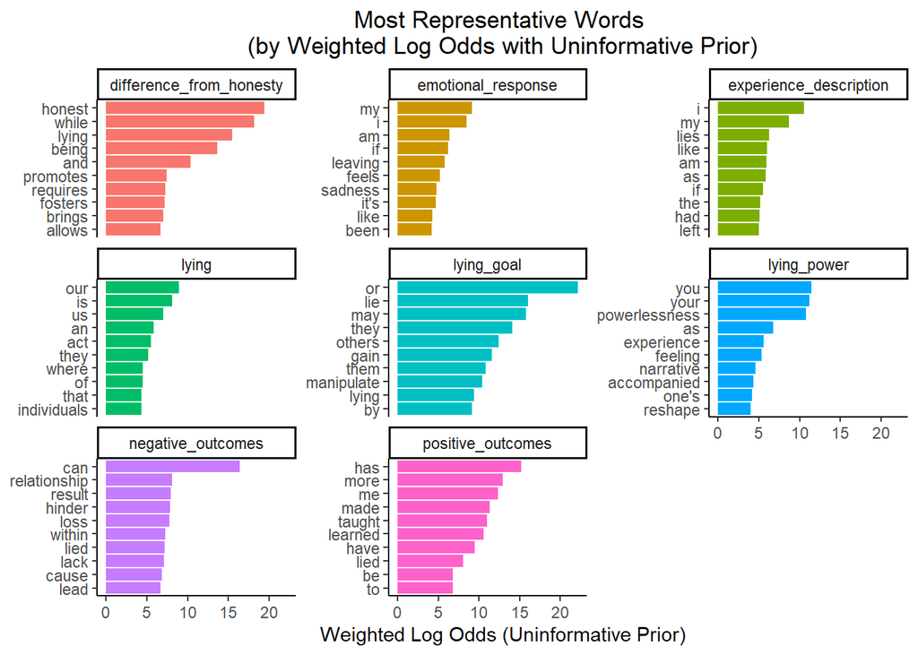

```r
lying_unnested_info %>%
  group_by(text_box) %>% ## Group by prompt
  slice_max(wlo_uninformative, n = 10, with_ties = FALSE) %>% ## Select the top 20 words with the highest weighted log odds (uninformative prior) values
  ungroup() %>%
  ggplot(aes(wlo_uninformative,
             reorder_within(word, wlo_uninformative, text_box),
             fill = text_box)) +  ## Map weighted log odds to x-axis, reorder words within each text_box, and use different colors
  geom_col(show.legend = FALSE) +  ## Create a column chart
  scale_y_reordered() +  ## Reorder y-axis based on the ordering of words
  facet_wrap(vars(text_box), scales = "free_y") + ## Create multiple facets based on text_box categories
  theme_classic() +  ## Use a classic theme for the plot
  theme(plot.title = element_text(hjust = 0.5)) +  ## Center-align the plot title
  labs(x = "Weighted Log Odds (Uninformative Prior)", y = NULL,
       title = "Most Representative Words \n(by Weighted Log Odds with Uninformative Prior)")  ## Set x-axis label, remove y-axis label, and set plot title
```

## 4.5 Which words are used more by people with more or less severe outcomes?

When we grouped our tokens, we averaged severity scores for each word used in each text box. We can use this to see which words are used by people with more/less severe outcomes.

```r
## Finding average severity rating across all participants
summary(lying_wide$rating_impact_severity)  ## Mean = 2.63
```

```
##    Min. 1st Qu.  Median    Mean 3rd Qu.    Max.    NA's
##   0.000   1.000   2.000   2.631   4.000   6.000      80
```

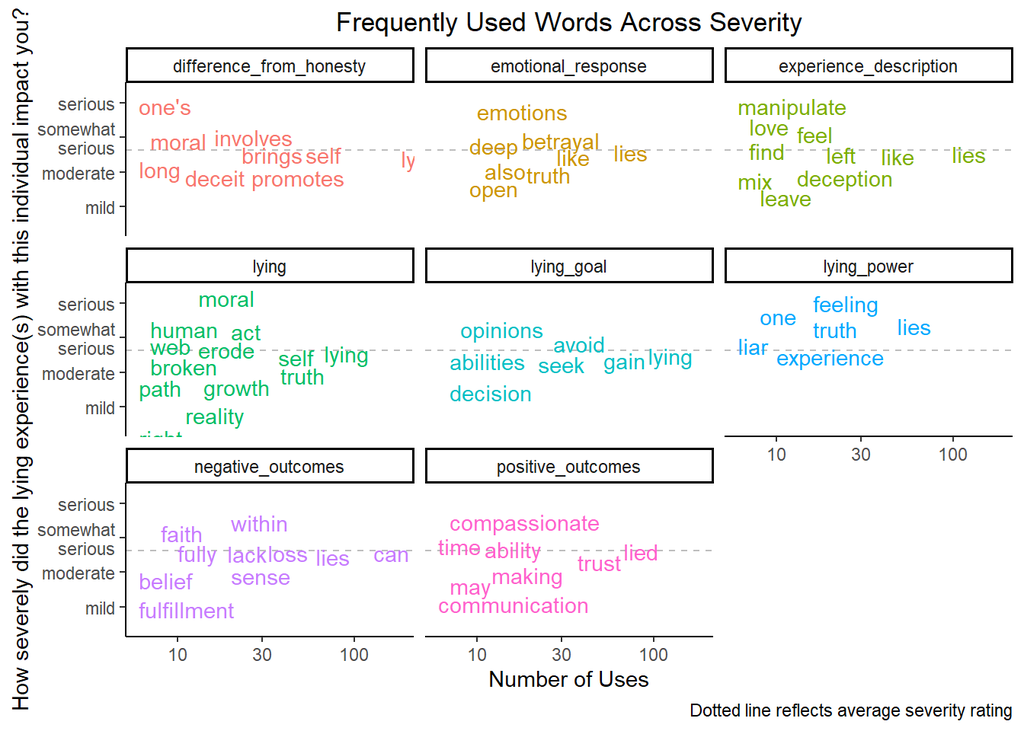

```r
## Make the dataframe
(frequently_used_words_across_severity <- token_counts_grouped %>%
  anti_join(get_stopwords()) %>%  ## Remove stopwords from the token counts
  filter(n > 5) %>% ## Filter out words that weren't used more than 5 times
  ggplot(data = ., aes(n, rating_impact_severity)) +  ## Map frequency (n) to x-axis and severity rating to y-axis
  geom_hline(yintercept = 2.63, lty = 2, color = "grey", size = 0.5) +  ## Add a dashed line representing the average severity rating
  geom_text(aes(label = word, color = text_box), check_overlap = TRUE, show.legend = FALSE, vjust = "top", hjust = "left") +  ## Add labels to the plot for each word, colored by text_box category
  facet_wrap(vars(text_box)) +  ## Create facets based on text_box categories
  scale_x_log10() +  ## Use a logarithmic scale for the x-axis
  scale_y_continuous(breaks = c(0, 1, 2, 3, 4, 5, 6),
                     labels = c("slight", "mild", "moderate", "somewhat\nserious", "serious", "severe", "very severe\nor traumatic")) +  ## Customize the y-axis labels
  theme_classic() + ## Use a classic theme for the plot
  theme(plot.title = element_text(hjust = 0.5)) + ## Center-align the plot title
  labs(x = "Number of Uses",
       y = "How severely did the lying experience(s) with this individual impact you?",
       caption = "Dotted line reflects average severity rating",
       title = "Frequently Used Words Across Severity"))  # Set x-axis label, y-axis label, caption, and plot title
```

## 4.6 Visualizing a network of bigrams with ggraph

To start getting a flavor for the kinds of longer phrases people used a lot, let’s make a word cloud with our bigrams. This way we can see which words are used next to eachother a lot, and the directionality/order.

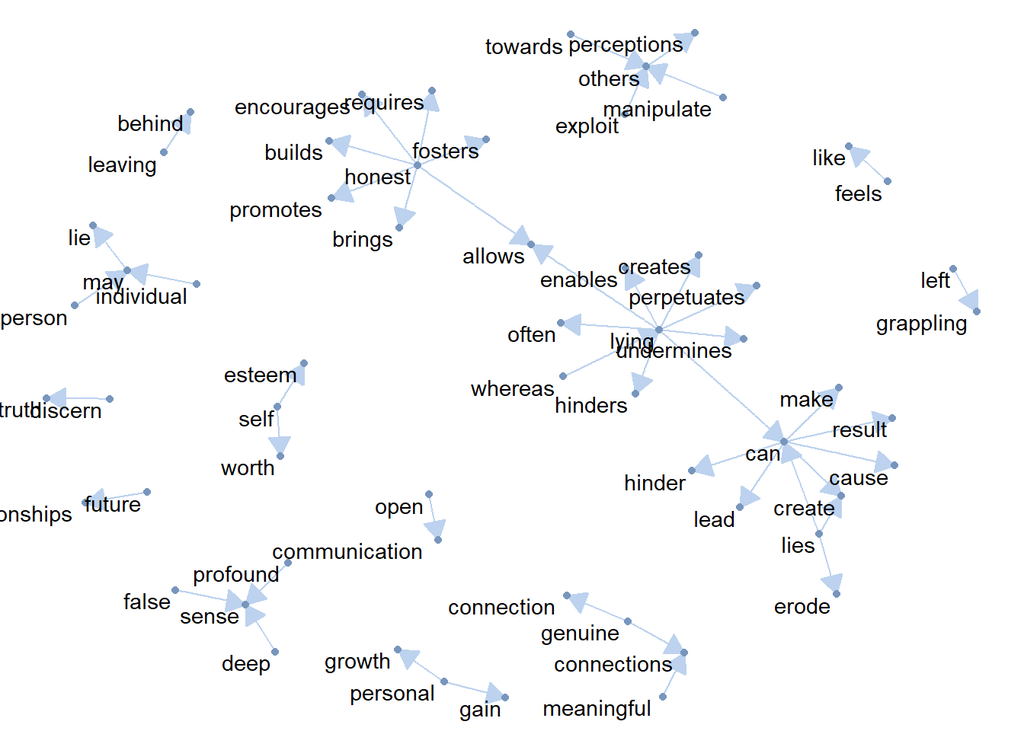

```r
## Prep some formatting for how we want our arrows to look
arrow_format <- grid::arrow(type = "closed", length = unit(.15, "inches"))

## Make the graph
bigram_counts %>%
  separate(bigram, c("word1", "word2"), sep = " ") %>%   ## Split the bigrams into individual words
  anti_join(get_stopwords(), by = c("word1" = "word")) %>%  ## Remove rows where the first word is a stopword
  anti_join(get_stopwords(), by = c("word2" = "word")) %>%  ## Remove rows where the second word is a stopword
  filter(n > 10, !is.na(word1), !is.na(word2)) %>%   ## Include full bigrams that were used more than twice
  graph_from_data_frame() %>%   ## Create a graph from the filtered data
  ggraph(layout = "fr") +   ## Use Fruchterman-Reingold layout algorithm
  geom_edge_link(color = "lightsteelblue2", arrow = arrow_format) + ## Set edge color and arrow style
  geom_node_point(color = "#7896BD", size = 1.5) +  ## Set node color and size
  geom_node_text(aes(label = name), vjust = 1.1, hjust = 1.1) + ## Display node labels
  theme_void()  ## Use a minimalistic theme
```